# Intro_GeoSpatial_Analysis

Mauro Mardones

2023-03-03

```r
library(sf)
```

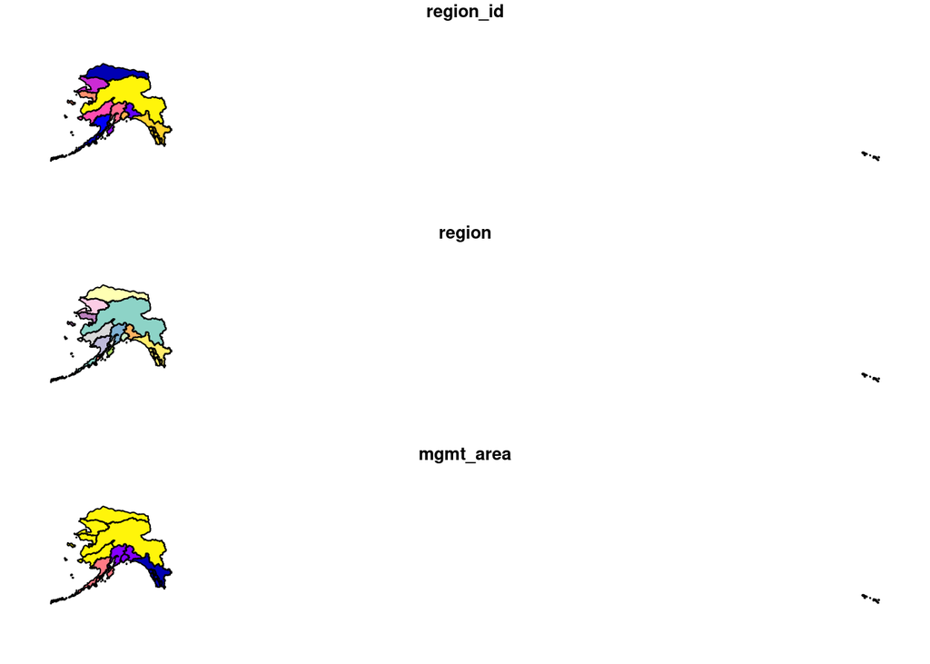

```r
library(ggplot2)
library(leaflet)
library(scales)
library(ggmap)
library(dplyr)
## Read in shapefile using sf
ak_regions <- read_sf("~/training_mardones/data/ak_regions_simp.shp")

plot(ak_regions)
```

```r
class(ak_regions)
```

```
## [1] "sf"         "tbl_df"     "tbl"        "data.frame"
```

Coordinate Reference System

Every sf object needs a coordinate reference system (or crs) defined in order to work with it correctly. A coordinate reference system contains both a datum and a projection. The datum is how you georeference your points (in 3 dimensions!) onto a spheroid. The projection is how these points are mathematically transformed to represent the georeferenced point on a flat piece of paper. All coordinate reference systems require a datum. However, some coordinate reference systems are “unprojected” (also called geographic coordinate systems). Coordinates in latitude/longitude use a geographic (unprojected) coordinate system. One of the most commonly used geographic coordinate systems is WGS 1984.

ESRI has a blog post that explains these concepts in more detail with very helpful diagrams and examples.

You can view what crs is set by using the function `st_crs`

```r
st_crs(ak_regions)
```

```
## Coordinate Reference System:
##   User input: WGS 84
##   wkt:
## GEOGCRS["WGS 84",
##     DATUM["World Geodetic System 1984",
##         ELLIPSOID["WGS 84",6378137,298.257223563,
##             LENGTHUNIT["metre",1]]],
##     PRIMEM["Greenwich",0,
##         ANGLEUNIT["degree",0.0174532925199433]],
##     CS[ellipsoidal,2],
##         AXIS["latitude",north,
##             ORDER[1],
##             ANGLEUNIT["degree",0.0174532925199433]],
##         AXIS["longitude",east,
##             ORDER[2],
##             ANGLEUNIT["degree",0.0174532925199433]],
##     ID["EPSG",4326]]
```

This is pretty confusing looking. Without getting into the details, that long string says that this data has a greographic coordinate system (WGS84) with no projection. A convenient way to reference crs quickly is by using the EPSG code, a number that represents a standard projection and datum. You can check out a list of (lots!) of EPSG codes [here](https://spatialreference.org/ref/epsg/?page=1).

We will use several EPSG codes in this lesson. Here they are, along with their more readable names:

3338: Alaska Albers 4326: WGS84 (World Geodetic System 1984), used in GPS 3857: Pseudo-Mercator, used in Google Maps, OpenStreetMap, Bing, ArcGIS, ESRI You will often need to transform your geospatial data from one coordinate system to another. The st_transform function does this quickly for us. You may have noticed the maps above looked wonky because of the dateline. We might want to set a different projection for this data so it plots nicer. A good one for Alaska is called the Alaska Albers projection, with an EPSG code of 3338.

```r
ak_regions_3338 <- ak_regions %>%
  st_transform(crs = 3338)

st_crs(ak_regions_3338)
```

```
## Coordinate Reference System:
##   User input: EPSG:3338
##   wkt:
## PROJCRS["NAD83 / Alaska Albers",
##     BASEGEOGCRS["NAD83",
##         DATUM["North American Datum 1983",
##             ELLIPSOID["GRS 1980",6378137,298.257222101,
##                 LENGTHUNIT["metre",1]]],
##         PRIMEM["Greenwich",0,
##             ANGLEUNIT["degree",0.0174532925199433]],
##         ID["EPSG",4269]],
##     CONVERSION["Alaska Albers (meters)",
##         METHOD["Albers Equal Area",
##             ID["EPSG",9822]],
##         PARAMETER["Latitude of false origin",50,
##             ANGLEUNIT["degree",0.0174532925199433],
##             ID["EPSG",8821]],
##         PARAMETER["Longitude of false origin",-154,
##             ANGLEUNIT["degree",0.0174532925199433],
##             ID["EPSG",8822]],
##         PARAMETER["Latitude of 1st standard parallel",55,
##             ANGLEUNIT["degree",0.0174532925199433],
##             ID["EPSG",8823]],
##         PARAMETER["Latitude of 2nd standard parallel",65,
##             ANGLEUNIT["degree",0.0174532925199433],
##             ID["EPSG",8824]],
##         PARAMETER["Easting at false origin",0,
##             LENGTHUNIT["metre",1],
##             ID["EPSG",8826]],
##         PARAMETER["Northing at false origin",0,
##             LENGTHUNIT["metre",1],
##             ID["EPSG",8827]]],
##     CS[Cartesian,2],
##         AXIS["easting (X)",east,
##             ORDER[1],
##             LENGTHUNIT["metre",1]],
##         AXIS["northing (Y)",north,
##             ORDER[2],
##             LENGTHUNIT["metre",1]],
##     USAGE[
##         SCOPE["Topographic mapping (small scale)."],
##         AREA["United States (USA) - Alaska."],
##         BBOX[51.3,172.42,71.4,-129.99]],
##     ID["EPSG",3338]]
```

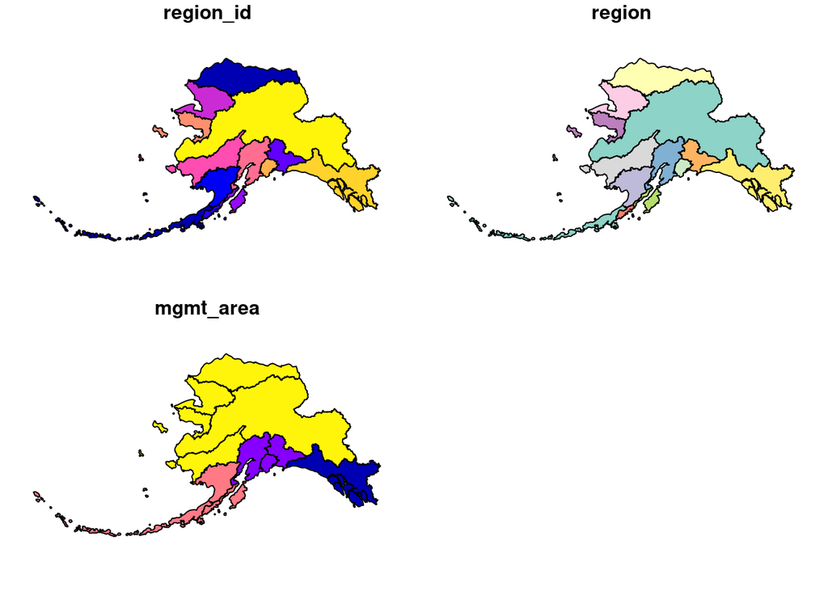

```r
plot(ak_regions_3338)
```

Since sf objects are `data.frames`, they play nicely with packages in the tidyverse. Here are a couple of simple examples:

`select()`

```r
ak_regions_3338 %>%
  select(region)
```

```
## Simple feature collection with 13 features and 1 field
## Geometry type: MULTIPOLYGON
## Dimension:     XY
## Bounding box:  xmin: -2175328 ymin: 405653 xmax: 1579226 ymax: 2383770
## Projected CRS: NAD83 / Alaska Albers
## # A tibble: 13 × 2
##    region                                                               geometry
##    <chr>                                                      <MULTIPOLYGON [m]>
##  1 Aleutian Islands     (((-1156666 420855.1, -1159837 417990.3, -1161898 41694…
##  2 Arctic               (((571289.9 2143072, 569941.5 2142691, 569158.2 2142146…
##  3 Bristol Bay          (((-339688.6 973904.9, -339302 972297.3, -339229.2 9710…
##  4 Chignik              (((-114381.9 649966.8, -112866.8 652065.8, -108836.8 65…
##  5 Copper River         (((561012 1148301, 559393.7 1148169, 557797.7 1148492, …
##  6 Kodiak               (((115112.5 983293, 113051.3 982825.9, 110801.3 983211.…
##  7 Kotzebue             (((-678815.3 1819519, -677555.2 1820698, -675557.8 1821…
##  8 Kuskokwim            (((-1030125 1281198, -1029858 1282333, -1028980 1284032…
##  9 Cook Inlet           (((35214.98 1002457, 36660.3 1002038, 36953.11 1001186,…
## 10 Norton Sound         (((-848357 1636692, -846510 1635203, -840513.7 1632225,…
## 11 Prince William Sound (((426007.1 1087250, 426562.5 1088591, 427711.6 1089991…
## 12 Southeast            (((1287777 744574.1, 1290183 745970.8, 1292940 746262.7…
## 13 Yukon                (((-375318 1473998, -373723.9 1473487, -373064.8 147393…
```

```r
ak_regions_3338 %>%
  filter(region == "Southeast")
```

```
## Simple feature collection with 1 feature and 3 fields
## Geometry type: MULTIPOLYGON
## Dimension:     XY
## Bounding box:  xmin: 559475.7 ymin: 722450 xmax: 1579226 ymax: 1410576
## Projected CRS: NAD83 / Alaska Albers
## # A tibble: 1 × 4
##   region_id region    mgmt_area                                         geometry
## *     <int> <chr>         <dbl>                               <MULTIPOLYGON [m]>
## 1        12 Southeast         1 (((1287777 744574.1, 1290183 745970.8, 1292940 …
```

## Join

You can also use the sf package to create spatial joins, useful for when you want to utilize two datasets together. As an example, let’s ask a question: how many people live in each of these Alaska regions?

We have some population data, but it gives the number of people by city, not by region. To determine the number of people per region we will need to:

read in the city data from a csv and turn it into an sf object use a spatial join (st_join) to assign each city to a region use group_by and summarize to calculate the total population by region First, read in the population data as a regular data.frame. This data is derived from: Jeanette Clark, Sharis Ochs, Derek Strong, and National Historic Geographic Information System. 2018. Languages used in Alaskan households, 1990-2015. Knowledge Network for Biocomplexity. doi:10.5063/F11G0JHX. Unnecessary columns were removed and the most recent year of data was selected.

```r
pop <- read.csv("~/training_mardones/data/alaska_population.csv")
```

```r
pop_4326 <- st_as_sf(pop,
                  coords = c('lng', 'lat'),
                  crs = 4326,
                  remove = F)

head(pop_4326)
```

```
## Simple feature collection with 6 features and 5 fields
## Geometry type: POINT
## Dimension:     XY
## Bounding box:  xmin: -176.6581 ymin: 51.88 xmax: -154.1703 ymax: 62.68889
## Geodetic CRS:  WGS 84
##   year     city      lat       lng population                   geometry
## 1 2015     Adak 51.88000 -176.6581        122    POINT (-176.6581 51.88)
## 2 2015   Akhiok 56.94556 -154.1703         84 POINT (-154.1703 56.94556)
## 3 2015 Akiachak 60.90944 -161.4314        562 POINT (-161.4314 60.90944)
## 4 2015    Akiak 60.91222 -161.2139        399 POINT (-161.2139 60.91222)
## 5 2015   Akutan 54.13556 -165.7731        899 POINT (-165.7731 54.13556)
## 6 2015 Alakanuk 62.68889 -164.6153        777 POINT (-164.6153 62.68889)
```

```r
pop_3338 <- st_transform(pop_4326, crs = 3338)
```

```r
pop_joined <- st_join(pop_3338, ak_regions_3338, join = st_within)

head(pop_joined)
```

```
## Simple feature collection with 6 features and 8 fields
## Geometry type: POINT
## Dimension:     XY
## Bounding box:  xmin: -1537925 ymin: 472626.9 xmax: -10340.71 ymax: 1456223
## Projected CRS: NAD83 / Alaska Albers
##   year     city      lat       lng population region_id           region
## 1 2015     Adak 51.88000 -176.6581        122         1 Aleutian Islands
## 2 2015   Akhiok 56.94556 -154.1703         84         6           Kodiak
## 3 2015 Akiachak 60.90944 -161.4314        562         8        Kuskokwim
## 4 2015    Akiak 60.91222 -161.2139        399         8        Kuskokwim
## 5 2015   Akutan 54.13556 -165.7731        899         1 Aleutian Islands
## 6 2015 Alakanuk 62.68889 -164.6153        777        13            Yukon
##   mgmt_area                   geometry
## 1         3  POINT (-1537925 472626.9)
## 2         3 POINT (-10340.71 770998.4)
## 3         4  POINT (-400885.5 1236460)
## 4         4  POINT (-389165.7 1235475)
## 5         3 POINT (-766425.7 526057.8)
## 6         4  POINT (-539724.9 1456223)
```

```r
pop_region <- pop_joined %>%
  as.data.frame() %>%
  group_by(region) %>%
  summarise(total_pop = sum(population))

head(pop_region)
```

```
## # A tibble: 6 × 2
##   region           total_pop
##   <chr>                <int>
## 1 Aleutian Islands      8840
## 2 Arctic                8419
## 3 Bristol Bay           6947
## 4 Chignik                311
## 5 Cook Inlet          408254
## 6 Copper River          2294
```

```r
pop_region_3338 <- left_join(ak_regions_3338, pop_region)
```

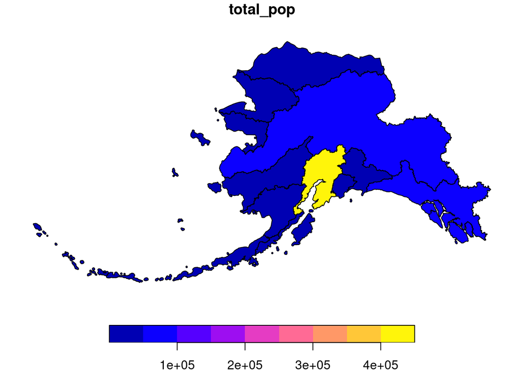

```r
#plot to check
plot(pop_region_3338["total_pop"])
```

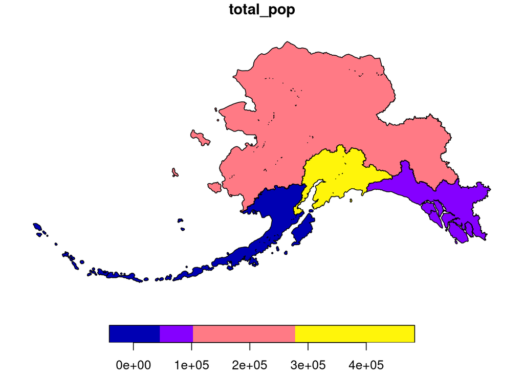

```r
pop_mgmt_338 <- pop_region_3338 %>%
  group_by(mgmt_area) %>%
  summarize(total_pop = sum(total_pop))

plot(pop_mgmt_338["total_pop"])
```

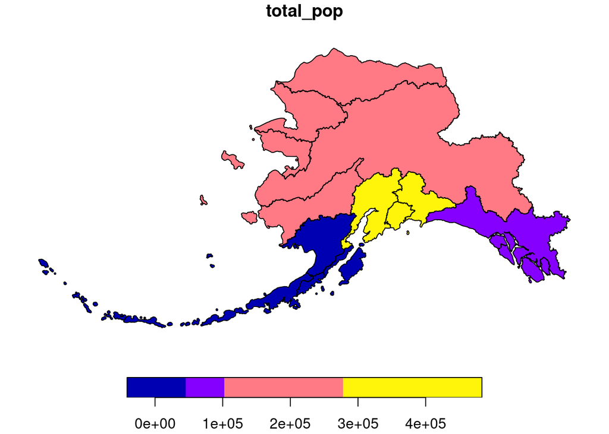

```r
pop_mgmt_3338 <- pop_region_3338 %>%
  group_by(mgmt_area) %>%
  summarize(total_pop = sum(total_pop), do_union = F)

plot(pop_mgmt_3338["total_pop"])
```

Writing the file

Save the spatial object to disk using `write_sf()` and specifying the filename. Writing your file with the extension .shp will assume an ESRI driver driver, but there are many other format options available.

```r
write_sf(pop_region_3338, "~/training_mardones/data/ak_regions_population.shp", delete_layer = TRUE)
```

## Vizualitation

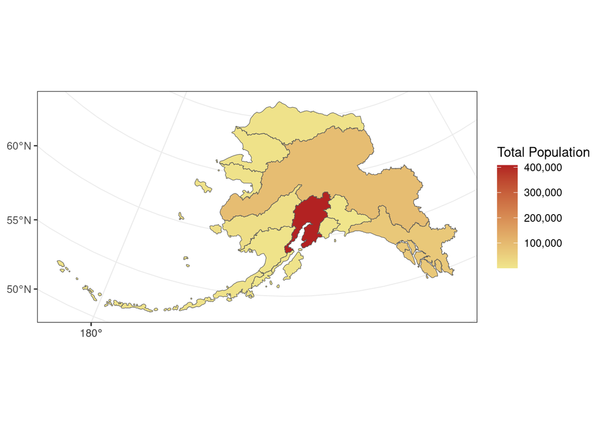

```r
ggplot(pop_region_3338) +
  geom_sf(aes(fill = total_pop)) +
  theme_bw() +
  labs(fill = "Total Population") +
  scale_fill_continuous(low = "khaki", high =  "firebrick", labels = comma)
```

```r
rivers_3338 <- read_sf("~/training_mardones/data/ak_rivers_simp.shp")
st_crs(rivers_3338)
```

```
## Coordinate Reference System:
##   User input: Albers
##   wkt:
## PROJCRS["Albers",
##     BASEGEOGCRS["GCS_GRS 1980(IUGG, 1980)",
##         DATUM["D_unknown",
##             ELLIPSOID["GRS80",6378137,298.257222101,
##                 LENGTHUNIT["metre",1,
##                     ID["EPSG",9001]]]],
##         PRIMEM["Greenwich",0,
##             ANGLEUNIT["Degree",0.0174532925199433]]],
##     CONVERSION["unnamed",
##         METHOD["Albers Equal Area",
##             ID["EPSG",9822]],
##         PARAMETER["Latitude of false origin",50,
##             ANGLEUNIT["Degree",0.0174532925199433],
##             ID["EPSG",8821]],
##         PARAMETER["Longitude of false origin",-154,
##             ANGLEUNIT["Degree",0.0174532925199433],
##             ID["EPSG",8822]],
##         PARAMETER["Latitude of 1st standard parallel",55,
##             ANGLEUNIT["Degree",0.0174532925199433],
##             ID["EPSG",8823]],
##         PARAMETER["Latitude of 2nd standard parallel",65,
##             ANGLEUNIT["Degree",0.0174532925199433],
##             ID["EPSG",8824]],
##         PARAMETER["Easting at false origin",0,
##             LENGTHUNIT["metre",1],
##             ID["EPSG",8826]],
##         PARAMETER["Northing at false origin",0,
##             LENGTHUNIT["metre",1],
##             ID["EPSG",8827]]],
##     CS[Cartesian,2],
##         AXIS["(E)",east,
##             ORDER[1],
##             LENGTHUNIT["metre",1,
##                 ID["EPSG",9001]]],
##         AXIS["(N)",north,
##             ORDER[2],
##             LENGTHUNIT["metre",1,
##                 ID["EPSG",9001]]]]
```

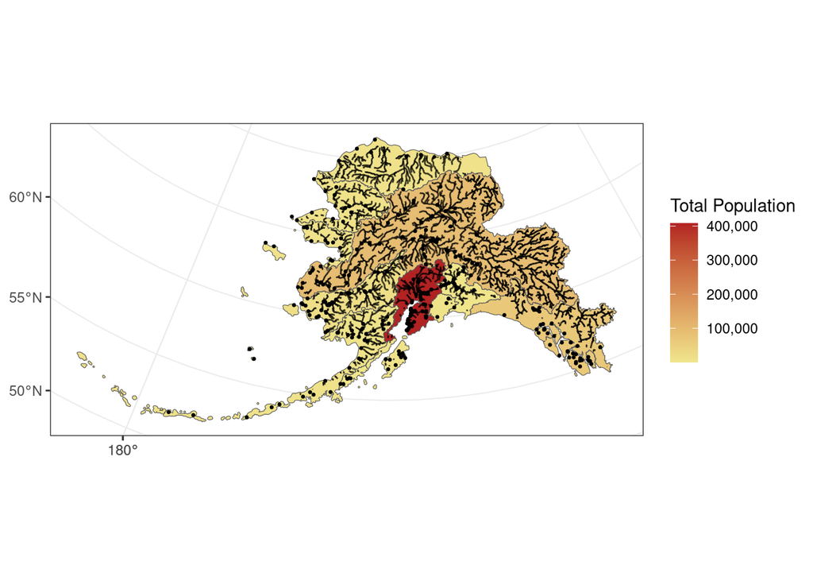

```r
ggplot() +
  geom_sf(data = pop_region_3338, aes(fill = total_pop)) +
  geom_sf(data = rivers_3338, aes(size = StrOrder), color = "black") +
  geom_sf(data = pop_3338, aes(), size = .5) +
  scale_size(range = c(0.01, 0.2), guide = F) +
  theme_bw() +
  labs(fill = "Total Population") +
  scale_fill_continuous(low = "khaki", high =  "firebrick", labels = comma)
```